# Day 4: Going Global

Cleo Falvey & Filip Stefanovic

2/23/2021

# Hello, World (literally!)

Since we can’t travel due to Covid-19, we are going to do some (virtual) travel. Let’s make some maps in R! By the end of this session, you will learn to make fun and visually engaging maps using the *rworldmap* package. First, we have to load all necessary libraries.

```r
library(tidyverse) # for cleaning data
library(sf) # for using shapefiles
```

```r
library(rworldmap) # for the world map
library(gapminder) # for country codes
```

# An Example Map

When we have global data like we do currently, it’s important to be able to visualize what is happening with it, typically on a map.

Today, we’ll be using the *rworldmaps* package, developed by Andy South, to make a map. The function we will be using, once we have organized our data, is the function below. The example is provided by the package authors and shows a heat map of the world’s population size.

```
## using example data because no file specified in rwmCheckAndLoadInput
```

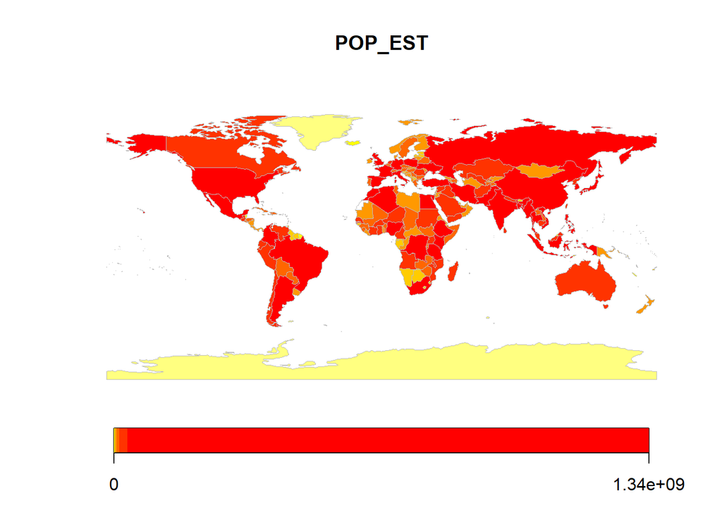

```r
mapCountryData()
```

# Our Data

We’re going to be using data from GapMinder for this next section, similarly to what you will be doing for your assignment / presentation (whatever you so choose).

I’ve chosen to graph life expectancy!

```r
life_expectancy <- read_csv("life_expectancy_years.csv")
head(life_expectancy)
```

```
## # A tibble: 6 x 302
##   country  `1800` `1801` `1802` `1803` `1804` `1805` `1806` `1807` `1808` `1809`
##   <chr>     <dbl>  <dbl>  <dbl>  <dbl>  <dbl>  <dbl>  <dbl>  <dbl>  <dbl>  <dbl>
## 1 Afghani~   28.2   28.2   28.2   28.2   28.2   28.2   28.1   28.1   28.1   28.1
## 2 Albania    35.4   35.4   35.4   35.4   35.4   35.4   35.4   35.4   35.4   35.4
## 3 Algeria    28.8   28.8   28.8   28.8   28.8   28.8   28.8   28.8   28.8   28.8
## 4 Andorra    NA     NA     NA     NA     NA     NA     NA     NA     NA     NA
## 5 Angola     27     27     27     27     27     27     27     27     27     27
## 6 Antigua~   33.5   33.5   33.5   33.5   33.5   33.5   33.5   33.5   33.5   33.5
## # ... with 291 more variables: 1810 <dbl>, 1811 <dbl>, 1812 <dbl>, 1813 <dbl>,
## #   1814 <dbl>, 1815 <dbl>, 1816 <dbl>, 1817 <dbl>, 1818 <dbl>, 1819 <dbl>,
## #   1820 <dbl>, 1821 <dbl>, 1822 <dbl>, 1823 <dbl>, 1824 <dbl>, 1825 <dbl>,
## #   1826 <dbl>, 1827 <dbl>, 1828 <dbl>, 1829 <dbl>, 1830 <dbl>, 1831 <dbl>,
## #   1832 <dbl>, 1833 <dbl>, 1834 <dbl>, 1835 <dbl>, 1836 <dbl>, 1837 <dbl>,
## #   1838 <dbl>, 1839 <dbl>, 1840 <dbl>, 1841 <dbl>, 1842 <dbl>, 1843 <dbl>,
## #   1844 <dbl>, 1845 <dbl>, 1846 <dbl>, 1847 <dbl>, 1848 <dbl>, 1849 <dbl>,
## #   1850 <dbl>, 1851 <dbl>, 1852 <dbl>, 1853 <dbl>, 1854 <dbl>, 1855 <dbl>,
## #   1856 <dbl>, 1857 <dbl>, 1858 <dbl>, 1859 <dbl>, 1860 <dbl>, 1861 <dbl>,
## #   1862 <dbl>, 1863 <dbl>, 1864 <dbl>, 1865 <dbl>, 1866 <dbl>, 1867 <dbl>,
## #   1868 <dbl>, 1869 <dbl>, 1870 <dbl>, 1871 <dbl>, 1872 <dbl>, 1873 <dbl>,
## #   1874 <dbl>, 1875 <dbl>, 1876 <dbl>, 1877 <dbl>, 1878 <dbl>, 1879 <dbl>,
## #   1880 <dbl>, 1881 <dbl>, 1882 <dbl>, 1883 <dbl>, 1884 <dbl>, 1885 <dbl>,
## #   1886 <dbl>, 1887 <dbl>, 1888 <dbl>, 1889 <dbl>, 1890 <dbl>, 1891 <dbl>,
## #   1892 <dbl>, 1893 <dbl>, 1894 <dbl>, 1895 <dbl>, 1896 <dbl>, 1897 <dbl>,
## #   1898 <dbl>, 1899 <dbl>, 1900 <dbl>, 1901 <dbl>, 1902 <dbl>, 1903 <dbl>,
## #   1904 <dbl>, 1905 <dbl>, 1906 <dbl>, 1907 <dbl>, 1908 <dbl>, 1909 <dbl>, ...
```

We can see that the structure of the data seems to show the country, year, and life expectancy. We will want to clean this, and select only one year to map. Let’s select 2021. One way to do this is to pivot the data so that it is *longer*. This will mean we will have a data set that looks something like this, with country, year, and life expectancy paired together.

To do this, we are going to use *pivot_longer()*. The first argument of the function takes the columns that we are pivoting (below, 2:302 is the index of the columns. If you look at the original dataset, you will see that those are all the years for which life expectancy was predicted by GapMinder. Remember, arrays in R start at 1.) The next argument tells us what we are going to rename the names and values of the data set!

```r
life_expectancy2 <- life_expectancy %>%
  pivot_longer(2:302,names_to = "year", values_to="life_expectancy")

head(life_expectancy2)
```

```
## # A tibble: 6 x 3
##   country     year  life_expectancy
##   <chr>       <chr>           <dbl>
## 1 Afghanistan 1800             28.2
## 2 Afghanistan 1801             28.2
## 3 Afghanistan 1802             28.2
## 4 Afghanistan 1803             28.2
## 5 Afghanistan 1804             28.2
## 6 Afghanistan 1805             28.2
```

```r
life_expectancy3 <- life_expectancy2 %>%
  filter(year==2021)

head(life_expectancy3)
```

```
## # A tibble: 6 x 3
##   country             year  life_expectancy
##   <chr>               <chr>           <dbl>
## 1 Afghanistan         2021             64.7
## 2 Albania             2021             78.7
## 3 Algeria             2021             78.5
## 4 Andorra             2021             NA
## 5 Angola              2021             65.7
## 6 Antigua and Barbuda 2021             77.5
```

```r
life_expectancy4 <- left_join(life_expectancy3, country_codes, by=c("country"="country"))
```

Now we are going to join our country map data and our life expectancy data together to map it. This is going to be a little bit different than doing a left, right, or full join than before because this package seems to have its own joining function called *joinCountry2Datamap()*. The arguments are the data frame that we are joining, what country identifier we are joining by (the ISO-3166 code is what I am using), and what name that column is.

```r
map_this <- joinCountryData2Map(dF = life_expectancy4, joinCode="ISO3", nameJoinColumn = "iso_alpha")
```

```
## 170 codes from your data successfully matched countries in the map
## 17 codes from your data failed to match with a country code in the map
## 73 codes from the map weren't represented in your data
```

To check if our joining function worked, we will run the *class()* function on our object called *map_this*. We should see that it is a spatial polygons data frame, meaning that we have now successfully joined our information about our countries (lifespan and year) to the shapefiles of the countries, so we can graph them on a map.

```r
class(map_this)
```

```
## [1] "SpatialPolygonsDataFrame"
## attr(,"package")
## [1] "sp"
```

We can then use the function *mapCountryData()* to map our new map. If you want to customize the graph, something that can be helpful is typing the function name and hitting the tab button so you can see what arguments can be put into the function to customize it. You can also type help(mapCountryData) to view their help page and look at all of the arguments.

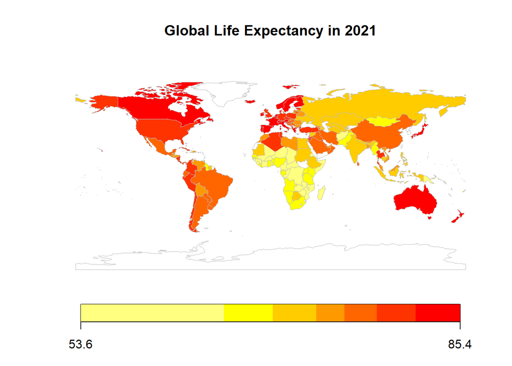

```r
mapCountryData(mapToPlot = map_this, nameColumnToPlot = "life_expectancy", mapTitle = "Global Life Expectancy in 2021")
```

This map looks really interesting! We can see that the life expectancy ranges by country, with certain regions of the world having much lower life expectancy than others.

One drawback to maps, especially global maps, is the fact that although the data is all there, it can be hard to zoom in on different areas of the map. Luckily, the package has recognized this and allowed the argument mapRegion, which takes character vectors of different continents.

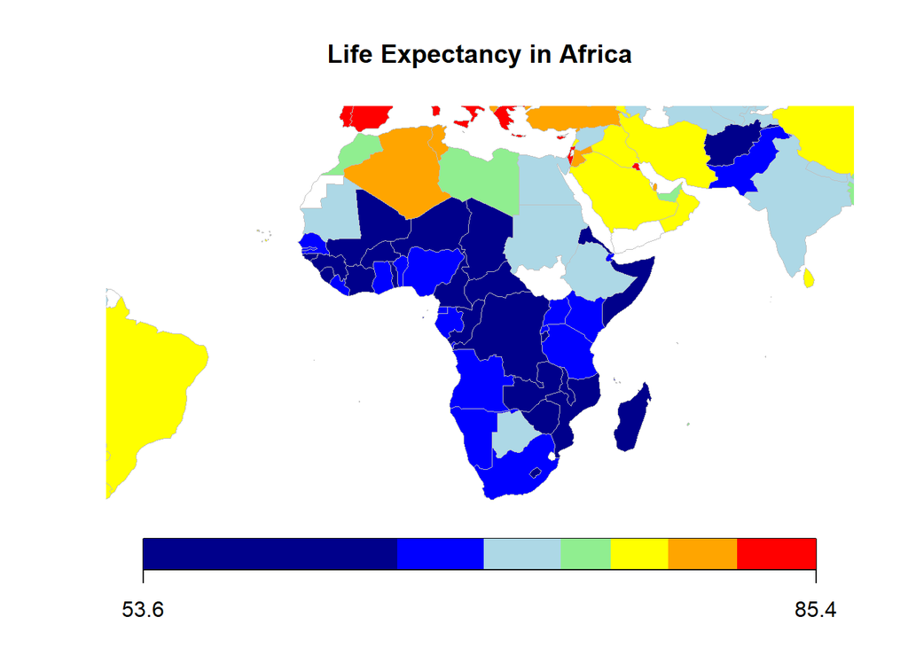

```r
mapCountryData(mapToPlot = map_this, nameColumnToPlot = "life_expectancy", mapRegion = "Africa", mapTitle = "Life Expectancy in Africa", colourPalette="negpos8")
```

You might have noticed that this mapping package is slightly different than *ggplot2*. There are multiple ways to map things in R, but this package is probably (in my opinion) pretty useful and intuitive.

Let’s try another example! What if we wanted to map something else?